# COMANDOS BASICOS R

# 4. regresiones lineales

Con los siguientes datos realizaremos la recta de regresión lineal

```r
tiempo2 <- c(0,1,2,3,4,5,6,7,8,9)
velocidad2 <- c(1.5,3,2.5,4,5.6,6,7.2,9.1,8.7,10)
# creamos la tabla de datos - data frame
datos2 <- data.frame(tiempo2,velocidad2)

datos2
```

```
##    tiempo2 velocidad2
## 1        0        1.5
## 2        1        3.0
## 3        2        2.5
## 4        3        4.0
## 5        4        5.6
## 6        5        6.0
## 7        6        7.2
## 8        7        9.1
## 9        8        8.7
## 10       9       10.0
```

```r
plot(datos2)
# La función de regresión lineal viene dada por la función lm(y~x)
# Recta de regresión de la variable "y" en funcion de la variable "x"

# ejecutamos la función lm() asignandole el nombre rl_velocidad_tiempo
reglin_velocidad2_tiempo2 <-lm(velocidad2~tiempo2, data=datos2)
reglin_velocidad2_tiempo2
```

```
##
## Call:
## lm(formula = velocidad2 ~ tiempo2, data = datos2)
##
## Coefficients:
## (Intercept)      tiempo2
##      1.4127       0.9661
```

```r
#otros datos estadisticos con la función summary()
summary(reglin_velocidad2_tiempo2)
```

```
##
## Call:
## lm(formula = velocidad2 ~ tiempo2, data = datos2)
##
## Residuals:
##      Min       1Q   Median       3Q      Max
## -0.84485 -0.29394 -0.05818  0.26409  0.92485
##
## Coefficients:
##             Estimate Std. Error t value Pr(>|t|)
## (Intercept)  1.41273    0.32386   4.362  0.00241 **
## tiempo2      0.96606    0.06067  15.924 2.42e-07 ***
## ---
## Signif. codes:  0 '***' 0.001 '**' 0.01 '*' 0.05 '.' 0.1 ' ' 1
##
## Residual standard error: 0.551 on 8 degrees of freedom
## Multiple R-squared:  0.9694, Adjusted R-squared:  0.9656
## F-statistic: 253.6 on 1 and 8 DF,  p-value: 2.422e-07
```

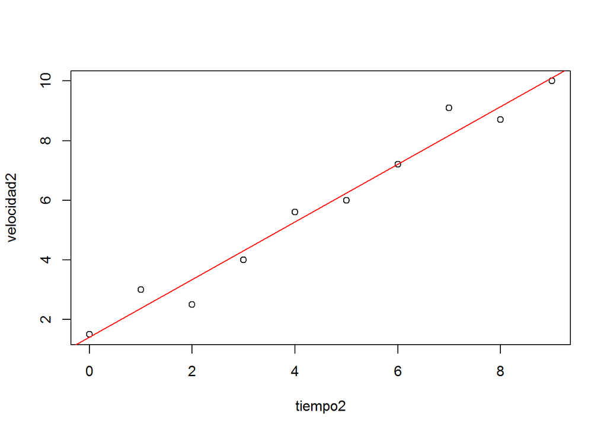

```r
# para graficar la recta, utilizamos la función abline
abline(reglin_velocidad2_tiempo2, col = "red")
```

# 5. construccion de vectores ## clases de vectores

```r
#1. Vectores numéricos----------------------------------
x <- c(1,2,3,4,5)
x
```

```
## [1] 1 2 3 4 5
```

```r
###     ¿Cómo saber? ###
#### mode(nombreObjeto)
#### typeof(nombreObjeto)

typeof(x)
```

```
## [1] "double"
```

```r
# 2. Vectores con carácteres----------------------------

letras <- c("a","b","casa","gato","perro","carro","tia")
letras
```

```
## [1] "a"     "b"     "casa"  "gato"  "perro" "carro" "tia"
```

```r
typeof(letras)
```

```
## [1] "character"
```

```r
# 3. Vector lógico------------------------
logico <- c(FALSE,TRUE)
logico
```

```
## [1] FALSE  TRUE
```

```r
typeof(logico)
```

```
## [1] "logical"
```

```r
mode(logico)
```

```
## [1] "logical"
```

```r
# 4. Vector de números complejos---------------------

complejos <- c(4i,3+7i,9i,12i)
complejos
```

```
## [1] 0+ 4i 3+ 7i 0+ 9i 0+12i
```

```r
mode(complejos)
```

```
## [1] "complex"
```

```r
# 5. Factores en vectores------------------------
genero<- (c("M","M","M","H","H"))
typeof(genero)
```

```
## [1] "character"
```

```r
genero2<- as.factor(genero)
genero2
```

```
## [1] M M M H H
## Levels: H M
```

```r
# 5.1 otro ejemplo

clases<- c(1,2,3,3,3,3,3,2,2,3,2,3,1)
typeof(clases)
```

```
## [1] "double"
```

```r
clases2<-as.factor(clases)
clases2
```

```
##  [1] 1 2 3 3 3 3 3 2 2 3 2 3 1
## Levels: 1 2 3
```

## 5.1 concatenar 2 o mas vectores

```r
union <- c(x,letras, complejos,5000)
union
```

```
##  [1] "1"     "2"     "3"     "4"     "5"     "a"     "b"     "casa"
##  [9] "gato"  "perro" "carro" "tia"   "0+4i"  "3+7i"  "0+9i"  "0+12i"
## [17] "5000"
```

```r
# cuando se une vectores de diferentes clases,
#r los interpreta como un único vector de clase " Character"
typeof(union)
```

```
## [1] "character"
```

```r
# 7. Otras formas de construir vectores------------------

# 7.1 Funcion Rep construir vectores repitiendo datos   rep(x, n)--------------

a <- rep(2,10)
a
```

```
##  [1] 2 2 2 2 2 2 2 2 2 2
```

```r
#7.1.1 Función rep(vector, times=n)--repite n veces en bloque el vector

s<- c(1,2,3)

s1<- rep(s, times =4)
s1
```

```
##  [1] 1 2 3 1 2 3 1 2 3 1 2 3
```

```r
#7.1.2 Función rep(vector, each=n)--repite n veces cada entrada del vector

s<- c(1,2,3)
s2<- rep(s, each =4)
s2
```

```
##  [1] 1 1 1 1 2 2 2 2 3 3 3 3
```

```r
# 8. progresiones artiméticas------------------------------

#Con la función "seq" inicio-final y los saltos

seq(0,30, by =5)
```

```
## [1]  0  5 10 15 20 25 30
```

```r
seq(100,12,by=-5)
```

```
##  [1] 100  95  90  85  80  75  70  65  60  55  50  45  40  35  30  25  20
## [18]  15
```

```r
# de otra manera :

0:10
```

```
##  [1]  0  1  2  3  4  5  6  7  8  9 10
```

```r
20:0
```

```
##  [1] 20 19 18 17 16 15 14 13 12 11 10  9  8  7  6  5  4  3  2  1  0
```

```r
# 9. Dar nombres a los elementos de un vector---------------


# # # # # #  DAR NOMBRE A LOS ELEMENTOS

x<- c(1,2,3)
names(x)<- c("Alex", "Beto", "Carlos")
x
```

```
##   Alex   Beto Carlos
##      1      2      3
```

```r
#Otro ejemplo

NOTAS<- c(4,4,4,4,1,4,5,2,5,5,3,3,4,5)
names(NOTAS)<- c("LUIS","MARIO", "MARIA","TERESA" ,"DANIEL", "FELIPE","JHON","CHRISTIAN",
                 "KARINA","RUBEN","MARCO","JOACHIM" ,"FERNANDO","ALFONSO")
NOTAS
```

```
##      LUIS     MARIO     MARIA    TERESA    DANIEL    FELIPE      JHON
##         4         4         4         4         1         4         5
## CHRISTIAN    KARINA     RUBEN     MARCO   JOACHIM  FERNANDO   ALFONSO
##         2         5         5         3         3         4         5
```

# 5.2. EXPLORACIÓN DE VECTORES

# 5.3 Estadísticos descriptivos——————–

mean(x)= promedio de los elementos de x median(x)= mediana de los elementos de x var(x)= varianza de los elementos de x (calculada en n-1) cov(x)= covarianza de los elementos de x

# 5.4 OTROS OPERADORES———————

round(x)= redondea los elémentos de x a n cifras decimales rev(x)= invierte el orden en los elementos de x sort(x)= oredena los elementos de x en forma ascendente,descendente “rev(sort(x))” match(x,y)= devuelve un vector de la misma longitud que x que estan en y (NA si no) which(x==a)= devuelve un vector de los indices de x si la operación es (TRUE)(En este #ejemplo #los valores de i para los cuales x[i]==a). El argumento de esta función debe ser una variable de tipo lógico #unique(x)= si x es un vector o un marco de datos, devuelve un objeto similar pero suprimiendo los elementos ducplicados

```r
#11.USO DE OPERADORES
#para este punto utilizaremos lo datos Rivers "Lengths of Major North American Rivers"
#que vienen dentro de los paquetes de ayuda en data()

data()
rivers
```

```
##   [1]  735  320  325  392  524  450 1459  135  465  600  330  336  280  315
##  [15]  870  906  202  329  290 1000  600  505 1450  840 1243  890  350  407
##  [29]  286  280  525  720  390  250  327  230  265  850  210  630  260  230
##  [43]  360  730  600  306  390  420  291  710  340  217  281  352  259  250
##  [57]  470  680  570  350  300  560  900  625  332 2348 1171 3710 2315 2533
##  [71]  780  280  410  460  260  255  431  350  760  618  338  981 1306  500
##  [85]  696  605  250  411 1054  735  233  435  490  310  460  383  375 1270
##  [99]  545  445 1885  380  300  380  377  425  276  210  800  420  350  360
## [113]  538 1100 1205  314  237  610  360  540 1038  424  310  300  444  301
## [127]  268  620  215  652  900  525  246  360  529  500  720  270  430  671
## [141] 1770
```

```r
rios<- rivers
rios
```

```
##   [1]  735  320  325  392  524  450 1459  135  465  600  330  336  280  315
##  [15]  870  906  202  329  290 1000  600  505 1450  840 1243  890  350  407
##  [29]  286  280  525  720  390  250  327  230  265  850  210  630  260  230
##  [43]  360  730  600  306  390  420  291  710  340  217  281  352  259  250
##  [57]  470  680  570  350  300  560  900  625  332 2348 1171 3710 2315 2533
##  [71]  780  280  410  460  260  255  431  350  760  618  338  981 1306  500
##  [85]  696  605  250  411 1054  735  233  435  490  310  460  383  375 1270
##  [99]  545  445 1885  380  300  380  377  425  276  210  800  420  350  360
## [113]  538 1100 1205  314  237  610  360  540 1038  424  310  300  444  301
## [127]  268  620  215  652  900  525  246  360  529  500  720  270  430  671
## [141] 1770
```

```r
# 10.1 Cuantos datos? length()


length(rios) #Cuantos datos?
```

```
## [1] 141
```

```r
sum(rios) # suma de todos los datos del vector
```

```
## [1] 83357
```

```r
# escoger datos puntuales de un vector []

rios[1]
```

```
## [1] 735
```

```r
rios[c(1,2)]
```

```
## [1] 735 320
```

```r
# cual es el río mas largo ?
which.max(rios)
```

```
## [1] 68
```

```r
# cual es la longitud ?
rios[68]
```

```
## [1] 3710
```

```r
# cual es el río mas corto?
which.min(rios)
```

```
## [1] 8
```

```r
# cual es la longitud ?
rios[8]
```

```
## [1] 135
```

```r
# estadisticos
# cual es el promedio de longitud de los ríos
mean(rios)
```

```
## [1] 591.1844
```

```r
# redondear el promedio a un decimal
round(mean(rios),1)
```

```
## [1] 591.2
```

```r
# cual es la mediana y var?
median(rios)
```

```
## [1] 425
```

```r
var(x)
```

```
## [1] 1
```

```r
# ordenar los elementos de rios en forma ascendente y guardarlo en la variable a

a<- sort(rios)

# ordenar de manera descendente

rev(a)
```

```
##   [1] 3710 2533 2348 2315 1885 1770 1459 1450 1306 1270 1243 1205 1171 1100
##  [15] 1054 1038 1000  981  906  900  900  890  870  850  840  800  780  760
##  [29]  735  735  730  720  720  710  696  680  671  652  630  625  620  618
##  [43]  610  605  600  600  600  570  560  545  540  538  529  525  525  524
##  [57]  505  500  500  490  470  465  460  460  450  445  444  435  431  430
##  [71]  425  424  420  420  411  410  407  392  390  390  383  380  380  377
##  [85]  375  360  360  360  360  352  350  350  350  350  340  338  336  332
##  [99]  330  329  327  325  320  315  314  310  310  306  301  300  300  300
## [113]  291  290  286  281  280  280  280  276  270  268  265  260  260  259
## [127]  255  250  250  250  246  237  233  230  230  217  215  210  210  202
## [141]  135
```

```r
# #match(x,y)= devuelve un vector de la misma longitud que x que estan en y (NA si no)

edades1 <- c(12,15,6,9,8,4,16,36,19,25,34,37,42)
edades2 <- c(12,15,68,75,43,98,72,69,83,44,42,21,46)
match(edades1,edades2)
```

```
##  [1]  1  2 NA NA NA NA NA NA NA NA NA NA 11
```

```r
#valores identicos

which(edades1==edades2)
```

```
## [1] 1 2
```

```r
# valores únicos
edades3 <- c(5,3,5,4,3,5,4,3,5,4,3,5,4,4,5,3)
unique(edades3)
```

```
## [1] 5 3 4
```

# 7. RUTA DE TRABAJO-LECTURA DE ARCHIVO DE DATOS

```r
library(ggplot2)
library(readr)


manizales <- read.csv("D:/CURSOS/Edx_R/HOME/PROJECTS/PROJECT_1/data/manizales_ppt.csv",header = FALSE, sep =",")

manizales
```

```
##      V1    V2    V3    V4    V5    V6    V7    V8    V9   V10   V11   V12
## 1  1968   0.0   0.0   0.0   0.0   0.0  12.7   5.7 137.0 178.0 255.0 185.0
## 2  1969 125.0  66.6   2.8 270.7 253.2 153.6   7.2   6.9 269.0   6.0  31.5
## 3  1970 174.6   1.0 107.2 210.7 237.5  55.6  61.2 135.5 180.1 234.3 285.2
## 4  1971 240.5 201.3 234.1 141.6 194.5  56.1  27.4 148.2  75.0 123.3 268.8
## 5  1972 120.3  70.0 220.9 220.6 192.1   1.6  67.3   3.0 113.9 136.2 108.7
## 6  1973  57.7   0.1 105.7 114.3  66.0 100.7  75.7 136.9 222.9 202.2 172.1
## 7  1974 112.0   7.1  47.2 154.3 159.4  69.8  40.7  59.3 202.3 261.5 186.2
## 8  1975  46.9 194.2 107.4 124.0 171.7  70.7 143.5 129.9 143.1 227.7 243.7
## 9  1976  55.8 158.1 131.2 221.7 125.6  71.9  12.6  26.7 118.8 234.1  65.7
## 10 1977  26.8  19.0  56.8 156.1 143.1 110.0   7.5  76.7 199.2 202.3 114.1
## 11 1978   9.8  47.0 146.2 274.5 159.9   0.6  68.0   6.0  75.0 188.0 219.5
## 12 1979  20.1  62.0 112.9 175.2  65.8   2.3  69.5 152.7 149.0 266.1 204.8
## 13 1980 170.9 136.8   0.3 134.3 182.2 110.5   7.1  45.1   4.3 112.2 158.4
## 14 1981  20.8 105.2 117.1 218.4 262.1 150.7  48.1 129.1 105.0 151.9 107.6
```

[output cut: 81 more lines]

## 7.1 cambiar de nombres

```r
names(manizales)<- c("YEAR", "ENERO", "FEBRERO", "MARZO", "ABRIL", "MAYO", "JUNIO", "JULIO", "AGOSTO", "SEPTIEMBRE", "OCTUBRE", "NOVIEMBRE", "DICIEMBRE", "TOTAL_ANUAL")

View(manizales)
```

## 7.3 qplot

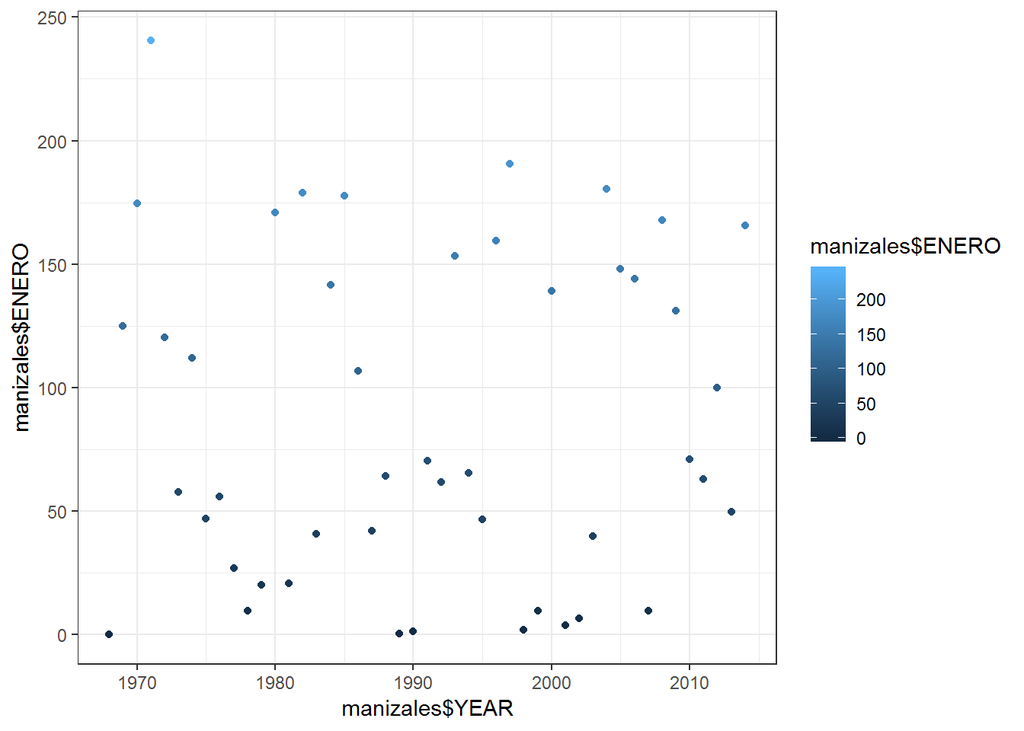

```r
# graficar year vs ENERO
qplot(manizales$YEAR,manizales$ENERO, color = manizales$ENERO, geom = "point")+
  theme_bw()
```

## 7.4seleccion de columnas especificas

```r
#seleccionar la primera y septima columna
jun_manizales<- manizales[,c(1,7)]

jun_manizales
```

```
##    YEAR JUNIO
## 1  1968  12.7
## 2  1969 153.6
## 3  1970  55.6
## 4  1971  56.1
## 5  1972   1.6
## 6  1973 100.7
## 7  1974  69.8
## 8  1975  70.7
## 9  1976  71.9
## 10 1977 110.0
## 11 1978   0.6
## 12 1979   2.3
## 13 1980 110.5
## 14 1981 150.7
```

[output cut: 33 more lines]

## 7.5 GUARDAR LA TABLA

```r
write.csv(jun_manizales, file = "D:/CURSOS/Edx_R/HOME/PROJECTS/PROJECT_1/data/jun_manizales.csv", append = FALSE, row.names = TRUE)
read.csv("D:/CURSOS/Edx_R/HOME/PROJECTS/PROJECT_1/data/jun_manizales.csv",header = TRUE, sep =",")
```

```
##     X YEAR JUNIO
## 1   1 1968  12.7
## 2   2 1969 153.6
## 3   3 1970  55.6
## 4   4 1971  56.1
## 5   5 1972   1.6
## 6   6 1973 100.7
## 7   7 1974  69.8
## 8   8 1975  70.7
## 9   9 1976  71.9
## 10 10 1977 110.0
## 11 11 1978   0.6
## 12 12 1979   2.3
## 13 13 1980 110.5
## 14 14 1981 150.7
```

[output cut: 33 more lines]